# LSTM-Calibrated SIR Model for COVID-19 Dynamics

Utah COVID-19 Case Prediction with Uncertainty Quantification

Author

Sima Najafzadehkhoei

Published

April 2, 2026

## Introduction

Calibrating an SIR model from real surveillance data requires estimating transmission probability and contact rate from a noisy incidence curve — a task that is computationally expensive when done with simulation-based methods. This vignette shows how `calibrate_sir()` solves this in seconds using a pretrained BiLSTM network, then quantifies prediction uncertainty by running 2,000 stochastic SIR simulations with the calibrated parameters.

## Setup

`calibrate_sir()` runs the BiLSTM model through a managed Python environment. If this is your **first time** using `epiworldRcalibrate` on this machine, run the one-time setup before loading the package:

```r
# Run once per machine, in a fresh R session
epiworldRcalibrate::setup_python_deps(force = TRUE)
```

In all subsequent sessions `force = FALSE` (the default) is sufficient to verify the environment is intact:

```r
epiworldRcalibrate::setup_python_deps()
```

```r
suppressPackageStartupMessages({
  library(tidyverse)
  library(ggplot2)
  library(epiworldR)
  library(epiworldRcalibrate)
})
```

## Data

We use `utah_covid_data` (shipped with the package), restricted to the most recent **61 days** — the sequence length the BiLSTM was trained on. Using fewer or more days would produce incorrect predictions.

```r
data("utah_covid_data")

last_date  <- max(utah_covid_data$Date, na.rm = TRUE)
covid_data <- utah_covid_data |>
  filter(Date > (last_date - 61)) |>
  arrange(Date)

incidence_vec <- covid_data$Daily.Cases
stopifnot(length(incidence_vec) == 61)

cat("Period:", as.character(min(covid_data$Date)),
    "to", as.character(max(covid_data$Date)), "\n")
```

```
Period: 2025-03-07 to 2025-05-06
```

```r
cat("Total cases:", sum(incidence_vec),
    "| Mean daily:", round(mean(incidence_vec), 1), "\n")
```

```
Total cases: 2034 | Mean daily: 33.3
```

## BiLSTM calibration

The recovery rate is fixed at $1/7$ (7-day mean infectious period), which is well established for COVID-19 and reduces the calibration problem to two unknowns: `ptran` and `crate`. The contact rate returned by the network is further constrained by the identity $\text{crate} = R_0 \times \text{recov} / \text{ptran}$, ensuring the three outputs are internally consistent.

```r
N     <- 5000
recov <- 1 / 7

lstm_predictions <- calibrate_sir(
  daily_cases     = incidence_vec,
  population_size = N,
  recovery_rate   = recov
)
```

```
Verifying Python packages...
```

```
[OK] numpy v2.0.2
```

```
[OK] sklearn v1.6.1
```

```
[OK] joblib v1.5.0
```

```
[OK] torch v2.7.0+cu126
```

```
All required Python packages are ready!
```

```
BiLSTM model loaded successfully.
```

```r
print(lstm_predictions)
```

```
     ptran      crate         R0
0.08302574 2.39933270 1.39444458
```

## Stochastic SIR simulation

With parameters in hand, we run 2,000 independent stochastic realisations of the SIR model. Each run represents one possible epidemic trajectory under the estimated transmission dynamics. Variation across runs reflects the randomness inherent in disease spread — who contacts whom on any given day — rather than uncertainty about the parameters themselves.

```r
model <- ModelSIRCONN(
  name              = "Utah LSTM-calibrated SIR",
  n                 = N,
  prevalence        = incidence_vec[1] / N,
  contact_rate      = lstm_predictions[["crate"]],
  transmission_rate = lstm_predictions[["ptran"]],
  recovery_rate     = recov
)

saver <- make_saver("transition")
run_multiple(model, ndays = 60, nsims = 2000,
             saver = saver, nthreads = 12)
```

```
Starting multiple runs (2000) using 12 thread(s)
_________________________________________________________________________
_________________________________________________________________________
||||||||||||||||||||||||||||||||||||||||||||||||||||||||||||||||||||||||| done.
```

```r
sim_results <- run_multiple_get_results(
  model, nthreads = 12, freader = data.table::fread)
```

We extract Susceptible → Infected transitions (new daily cases) and summarise across simulations to get the median and 95% prediction interval at each time step.

```r
quantiles_df <- sim_results$transition |>
  filter(from == "Susceptible", to == "Infected") |>
  group_by(date) |>
  summarize(lower_ci = quantile(counts, 0.025),
            upper_ci = quantile(counts, 0.975),
            median   = quantile(counts, 0.5),
            .groups  = "drop")
```

## Results

### Predictions vs observed cases

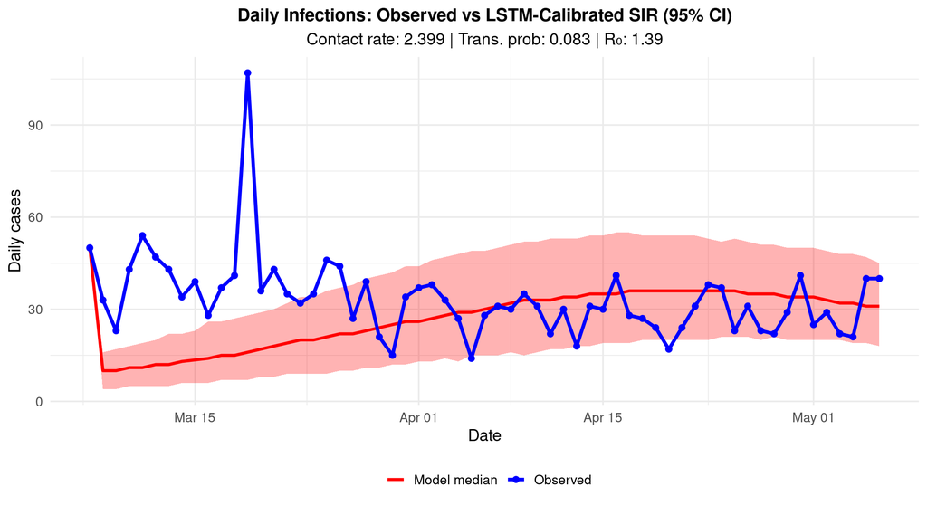

```r
plot_df <- quantiles_df |>
  mutate(Date           = covid_data$Date,
         observed_cases = incidence_vec)

ggplot(plot_df, aes(x = Date)) +
  geom_ribbon(aes(ymin = lower_ci, ymax = upper_ci),
              fill = "red", alpha = 0.3) +
  geom_line(aes(y = median, color = "Model median"),
            linewidth = 1.2) +
  geom_line(aes(y = observed_cases, color = "Observed"),
            linewidth = 1.4) +
  geom_point(aes(y = observed_cases, color = "Observed"), size = 2) +
  scale_color_manual(values = c("Model median" = "red",
                                "Observed"     = "blue")) +
  labs(
    title    = "Daily Infections: Observed vs LSTM-Calibrated SIR (95% CI)",
    subtitle = paste0(
      "Contact rate: ", round(lstm_predictions[["crate"]], 3),
      " | Trans. prob: ", round(lstm_predictions[["ptran"]], 3),
      " | R\u2080: ", round(lstm_predictions[["R0"]], 2)
    ),
    x = "Date", y = "Daily cases", color = ""
  ) +
  theme_minimal(base_size = 14) +
  theme(legend.position  = "bottom",
        plot.title       = element_text(size = 15, face = "bold", hjust = 0.5),
        plot.subtitle    = element_text(hjust = 0.5))
```

### Performance metrics

Three metrics assess how well the calibrated model fits the observed data. **Coverage** measures whether the prediction interval is appropriately wide — a well-calibrated 95% interval should contain roughly 95% of observed points. **RMSE** and **MAE** measure point prediction error on the median trajectory, with RMSE penalising large individual errors more heavily.

```r
coverage <- plot_df |>
  mutate(in_ci = observed_cases >= lower_ci & observed_cases <= upper_ci) |>
  summarize(rate = mean(in_ci) * 100, n_in = sum(in_ci), n = n())

rmse <- sqrt(mean((plot_df$median - plot_df$observed_cases)^2))
mae  <- mean(abs(plot_df$median - plot_df$observed_cases))

data.frame(
  Metric = c("95% CI Coverage (%)", "RMSE (cases/day)", "MAE (cases/day)"),
  Value  = c(round(coverage$rate, 1), round(rmse, 2), round(mae, 2))
) |> knitr::kable(caption = paste0(
  coverage$n_in, " of ", coverage$n, " observed days fall within the 95% CI"))
```

41 of 61 observed days fall within the 95% CI

| Metric | Value |
| --- | --- |
| 95% CI Coverage (%) | 67.20 |
| RMSE (cases/day) | 19.21 |
| MAE (cases/day) | 13.52 |

## Discussion

The BiLSTM estimated a transmission probability of **0.083**, a contact rate of **2.399** contacts per person per day, and $R_0 =$ **1.39**, with **67.2%** of observed days falling inside the 95% prediction interval and a mean absolute error of **13.52** cases per day.

The prediction interval reflects **simulation variance** — stochastic variation in who infects whom — rather than parameter uncertainty, since BiLSTM produces point estimates. If parameter uncertainty is also needed, the ABC approach in `vignette("bilstm-abc-comparison")` propagates a full posterior distribution through the simulations.

Key assumptions of this model worth noting: the population is treated as homogeneously mixed, parameters are held constant over the 60-day window, and the recovery rate is fixed rather than estimated. Each of these could be relaxed in extensions — for example by fitting a time-varying $\beta(t)$ or moving to an SEIR structure to account for a latent period.